# College Analysis_

### 1) Importing libraries:

```python
import pandas as pd
import matplotlib.pyplot as plt
import numpy as np
```

### 2) Reading the data:

```python
college = pd.read_csv("College.csv")
```

```python
college = college.rename({'Unnamed: 0':'College'},axis=1)
college = college.set_index("College")
college.head(5)
```

| College | Private | Apps | Accept | Enroll | Top10perc | Top25perc | F.Undergrad | P.Undergrad | Outstate | Room.Board | Books | Personal | PhD | Terminal | S.F.Ratio | perc.alumni | Expend | Grad.Rate |
| --- | --- | --- | --- | --- | --- | --- | --- | --- | --- | --- | --- | --- | --- | --- | --- | --- | --- | --- |
| Abilene Christian University | Yes | 1660 | 1232 | 721 | 23 | 52 | 2885 | 537 | 7440 | 3300 | 450 | 2200 | 70 | 78 | 18.1 | 12 | 7041 | 60 |
| Adelphi University | Yes | 2186 | 1924 | 512 | 16 | 29 | 2683 | 1227 | 12280 | 6450 | 750 | 1500 | 29 | 30 | 12.2 | 16 | 10527 | 56 |
| Adrian College | Yes | 1428 | 1097 | 336 | 22 | 50 | 1036 | 99 | 11250 | 3750 | 400 | 1165 | 53 | 66 | 12.9 | 30 | 8735 | 54 |
| Agnes Scott College | Yes | 417 | 349 | 137 | 60 | 89 | 510 | 63 | 12960 | 5450 | 450 | 875 | 92 | 97 | 7.7 | 37 | 19016 | 59 |
| Alaska Pacific University | Yes | 193 | 146 | 55 | 16 | 44 | 249 | 869 | 7560 | 4120 | 800 | 1500 | 76 | 72 | 11.9 | 2 | 10922 | 15 |

### 3) Analysis and Plotting:

```python
college.describe()
```

|  | Apps | Accept | Enroll | Top10perc | Top25perc | F.Undergrad | P.Undergrad | Outstate | Room.Board | Books | Personal | PhD | Terminal | S.F.Ratio | perc.alumni | Expend | Grad.Rate |
| --- | --- | --- | --- | --- | --- | --- | --- | --- | --- | --- | --- | --- | --- | --- | --- | --- | --- |
| count | 777.000000 | 777.000000 | 777.000000 | 777.000000 | 777.000000 | 777.000000 | 777.000000 | 777.000000 | 777.000000 | 777.000000 | 777.000000 | 777.000000 | 777.000000 | 777.000000 | 777.000000 | 777.000000 | 777.00000 |
| mean | 3001.638353 | 2018.804376 | 779.972973 | 27.558559 | 55.796654 | 3699.907336 | 855.298584 | 10440.669241 | 4357.526384 | 549.380952 | 1340.642214 | 72.660232 | 79.702703 | 14.089704 | 22.743887 | 9660.171171 | 65.46332 |
| std | 3870.201484 | 2451.113971 | 929.176190 | 17.640364 | 19.804778 | 4850.420531 | 1522.431887 | 4023.016484 | 1096.696416 | 165.105360 | 677.071454 | 16.328155 | 14.722359 | 3.958349 | 12.391801 | 5221.768440 | 17.17771 |
| min | 81.000000 | 72.000000 | 35.000000 | 1.000000 | 9.000000 | 139.000000 | 1.000000 | 2340.000000 | 1780.000000 | 96.000000 | 250.000000 | 8.000000 | 24.000000 | 2.500000 | 0.000000 | 3186.000000 | 10.00000 |
| 25% | 776.000000 | 604.000000 | 242.000000 | 15.000000 | 41.000000 | 992.000000 | 95.000000 | 7320.000000 | 3597.000000 | 470.000000 | 850.000000 | 62.000000 | 71.000000 | 11.500000 | 13.000000 | 6751.000000 | 53.00000 |
| 50% | 1558.000000 | 1110.000000 | 434.000000 | 23.000000 | 54.000000 | 1707.000000 | 353.000000 | 9990.000000 | 4200.000000 | 500.000000 | 1200.000000 | 75.000000 | 82.000000 | 13.600000 | 21.000000 | 8377.000000 | 65.00000 |
| 75% | 3624.000000 | 2424.000000 | 902.000000 | 35.000000 | 69.000000 | 4005.000000 | 967.000000 | 12925.000000 | 5050.000000 | 600.000000 | 1700.000000 | 85.000000 | 92.000000 | 16.500000 | 31.000000 | 10830.000000 | 78.00000 |
| max | 48094.000000 | 26330.000000 | 6392.000000 | 96.000000 | 100.000000 | 31643.000000 | 21836.000000 | 21700.000000 | 8124.000000 | 2340.000000 | 6800.000000 | 103.000000 | 100.000000 | 39.800000 | 64.000000 | 56233.000000 | 118.00000 |

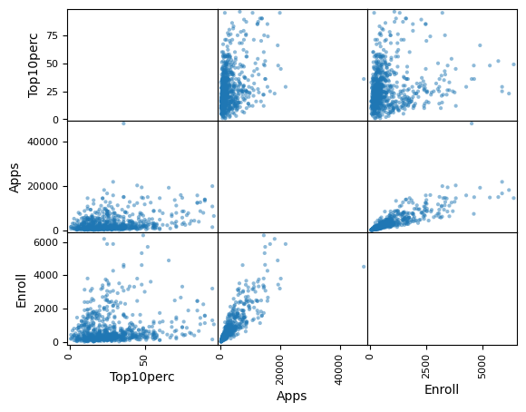

```python
scatter_matrix = pd.plotting.scatter_matrix(college[['Top10perc','Apps','Enroll']],diagonal='None');
```

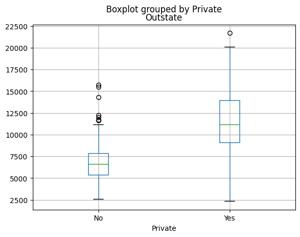

```python
college.boxplot(column = 'Outstate',by = 'Private')
```

#### From this plot we can see that the outstate fees is higher for private universities.

```python
college['Elite'] = pd.cut(college['Top10perc'],[0,50,100],labels=['No','Yes'])
college['Elite'].value_counts()
```

```
Elite
No     699
Yes     78
Name: count, dtype: int64
```

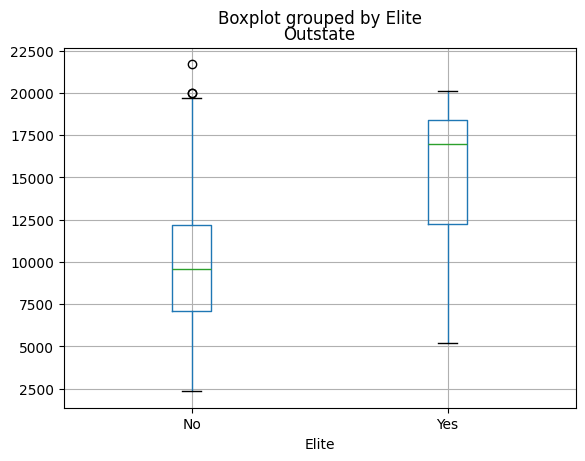

```python
college.boxplot(column='Outstate',by='Elite')
```

##### We categorized colleges based on the percentage of new students from the top 10% of their high school class ('Top10perc'). Colleges classified as 'Elite' represent institutions where more than 50% of incoming students come from the top 10% of their high school class. There is a notable difference in 'Outstate' tuition fees between colleges designated as 'Elite' and those outside this category. Colleges identified as 'Elite' consistently exhibit higher 'Outstate' tuition fees compared to their counterparts where fewer than 50% of students originate from the top 10% of their high school class.

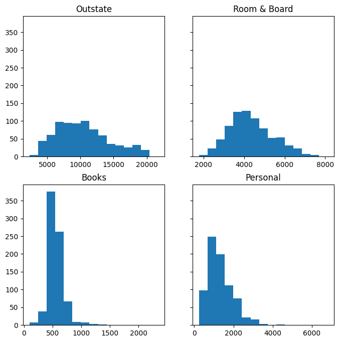

```python
fig,ax = plt.subplots(2,2,figsize=(8,8),sharey=True)
ax[0][0].hist(college['Outstate'],bins = 15)
ax[0][1].hist(college['Room.Board'],bins = 15)
ax[1][0].hist(college['Books'],bins = 15)
ax[1][1].hist(college['Personal'],bins = 15)
ax[0][0].set_title('Outstate')
ax[0][1].set_title('Room & Board')
ax[1][0].set_title('Books')
ax[1][1].set_title('Personal');
```

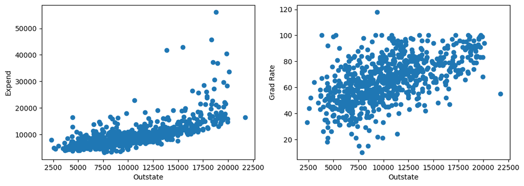

```python
fig2,ax2 = plt.subplots(1,2,figsize=(12,4))
ax2[0].scatter(college['Outstate'],college['Expend'])
ax2[1].scatter(college['Outstate'],college['Grad.Rate'])
ax2[0].set_xlabel('Outstate')
ax2[0].set_ylabel('Expend')
ax2[1].set_xlabel('Outstate')
ax2[1].set_ylabel('Grad Rate');
```

##### from this plot we can observe a positive correlation between higher out-of-state tuition fees ('Outstate') and both the instructional expenditure per student ('Expend') and the graduation rate ('Grad Rate'). Specifically, as the out-of-state tuition fees increase, there is a tendency for both the instructional expenditure per student and the graduation rate to also increase. This suggests that colleges with higher out-of-state tuition fees may allocate more resources towards instruction and student support services, potentially resulting in higher graduation rates."